# Projet_Forecasting

```
[1] "C:/Users/monke/Bureau/M2_FORECASTING/Projet"
```

Importation

GDP: PIB des USA en milliards de dollars TTLCONS: depenses en construction en millions de dollars

Ramener les TTLCONS en milliards de dollars

Predictions TTLCONS pour Avril, Mai, Juin (modele ARIN=MA) dans le but de pouvoir faire la prediction du PIB pour le 2e trimestre de 2024

Aggregation des donnees mensuelles pour les ramener au trimestre

Creation de jeu de donnees qui contient le PIB et les TTLCONS trimestrielles en milliards de dollars

On decide de creer une variable retard du PIB pour pouvoir faire le modele de bridge (Voir formule)

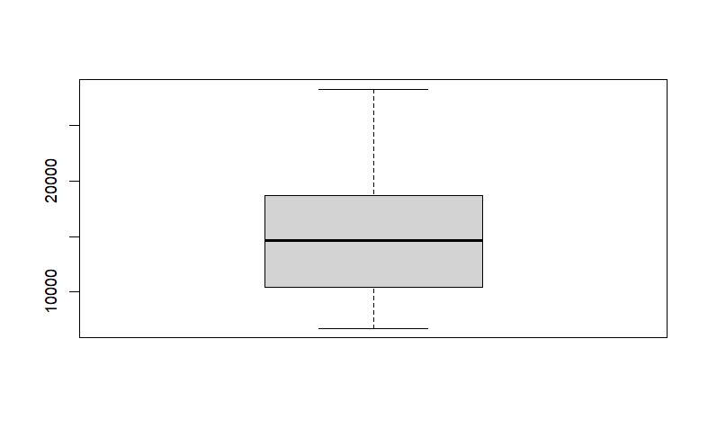

```
[1] 5623.268
```

# **Prevision Within Sample (WS)**

### MODELE BRIDGE

```
Call:
lm(formula = GDP ~ TTLCONS + lag_GDP, data = data)

Residuals:
     Min       1Q   Median       3Q      Max
-2052.90   -45.74     7.13    57.32  1443.54

Coefficients:
             Estimate Std. Error t value Pr(>|t|)
(Intercept) -57.38134   67.05994  -0.856   0.3939
TTLCONS       0.12517    0.05615   2.229   0.0276 *
lag_GDP       0.98939    0.01155  85.631   <2e-16 ***
---
Signif. codes:  0 ‘***’ 0.001 ‘**’ 0.01 ‘*’ 0.05 ‘.’ 0.1 ‘ ’ 1

Residual standard error: 256 on 122 degrees of freedom
Multiple R-squared:  0.998, Adjusted R-squared:  0.9979
F-statistic: 2.986e+04 on 2 and 122 DF,  p-value: < 2.2e-16
```

TTLCONS et lag_GDP significatifs au niveau 5% Modele globalement satisfaisant, car p-value du test de Fisher < 5% R2 = 99.8 %, Ce qui montre que les vqrs explicatives capturent bien la variance du PIB

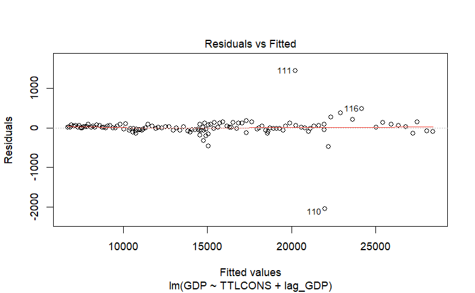

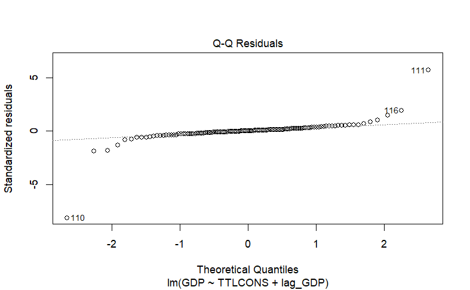

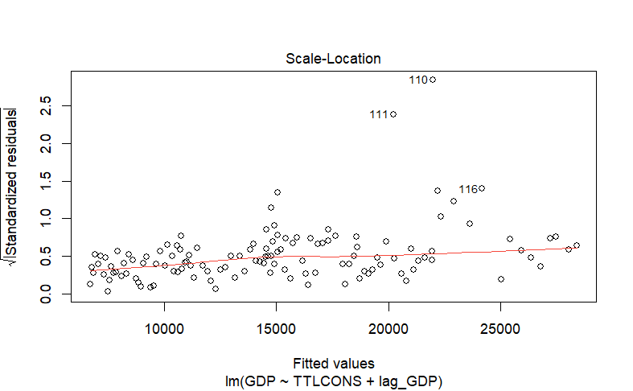

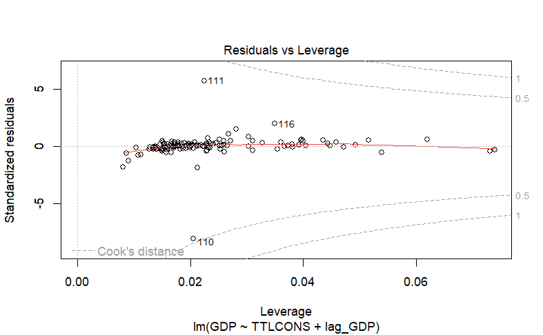

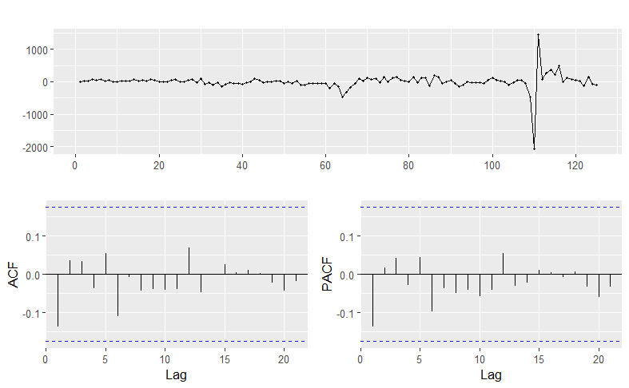

De plus residus sont non autocorreles. Les hypotheses sont verifiees.

Creer Series Temporelles pour les predictions

Tracer les predictions et l’intervalle de prediction

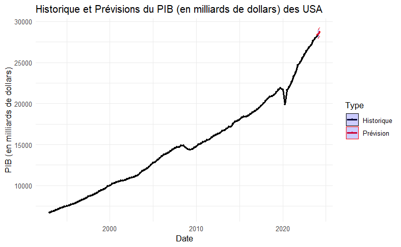

```
       fit      lwr      upr
1 28386.47 27861.58 28911.36
2 28717.93 28192.53 29243.33
```

### MIDAS Zero

```
MIDAS regression model with "ts" data:
Start = 1993(4), End = 2024(1)

 Formula GDP ~ mls(TTLCONS, 0:11, 3)

 Parameters:
             Estimate Std. Error t value Pr(>|t|)
(Intercept)  610.3681  2559.1484   0.239    0.812
TTLCONS1       6.8417    13.2328   0.517    0.606
TTLCONS2      20.1172    21.3915   0.940    0.349
TTLCONS3     -20.3820    20.9335  -0.974    0.332
TTLCONS4      -2.6168    30.9350  -0.085    0.933
TTLCONS5      10.1187    19.0057   0.532    0.596
TTLCONS6     -12.8138    26.8592  -0.477    0.634
TTLCONS7       1.2771    35.6233   0.036    0.971
TTLCONS8      17.3529    21.2281   0.817    0.415
TTLCONS9     -14.9899    23.7805  -0.630    0.530
TTLCONS10    -10.2166    27.9938  -0.365    0.716
TTLCONS11     18.7463    21.9744   0.853    0.395
TTLCONS12      0.6868    12.3706   0.056    0.956

 Residual standard error: 2051 on 109 degrees of freedom
```

Aucun Coef significatif au niveau 5%

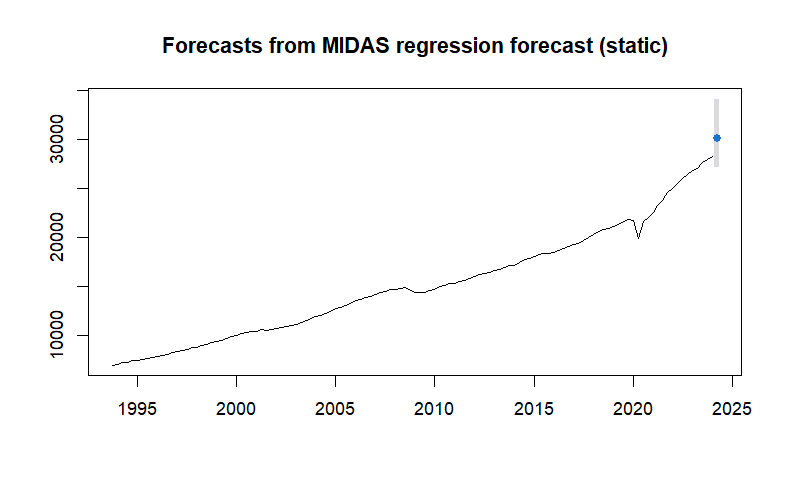

|  | Point Forecast | Lo 95 | Hi 95 |
| --- | --- | --- | --- |
| 2024 Q2 | 30137.69 | 27131.84 | 34106.66 |

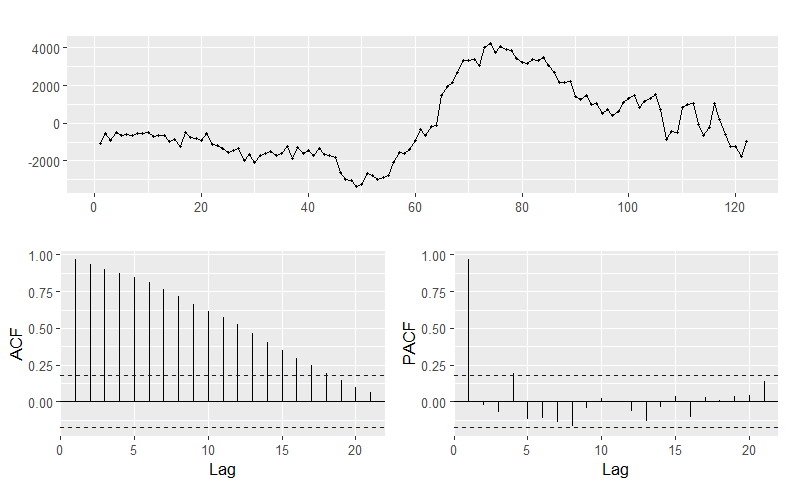

residus heteroscedasticiques, autocorreles Capacite predictive laisse a desirer

### MIDAS non Zero

```
MIDAS regression model with "ts" data:
Start = 1993(4), End = 2024(1)

 Formula GDP ~ mls(TTLCONS, 0:11, 3)

 Parameters:
             Estimate Std. Error t value Pr(>|t|)
(Intercept)  610.3681  2559.1484   0.239    0.812
TTLCONS1       6.8417    13.2328   0.517    0.606
TTLCONS2      20.1172    21.3915   0.940    0.349
TTLCONS3     -20.3820    20.9335  -0.974    0.332
TTLCONS4      -2.6168    30.9350  -0.085    0.933
TTLCONS5      10.1187    19.0057   0.532    0.596
TTLCONS6     -12.8138    26.8592  -0.477    0.634
TTLCONS7       1.2771    35.6233   0.036    0.971
TTLCONS8      17.3529    21.2281   0.817    0.415
TTLCONS9     -14.9899    23.7805  -0.630    0.530
TTLCONS10    -10.2166    27.9938  -0.365    0.716
TTLCONS11     18.7463    21.9744   0.853    0.395
TTLCONS12      0.6868    12.3706   0.056    0.956

 Residual standard error: 2051 on 109 degrees of freedom
```

meme coef que le model zero, cela signifie que Les données utilisées pour le modèle peuvent être suffisamment informatives pour guider le modèle vers des coefficients similaires, quelle que soit la valeur initiale.

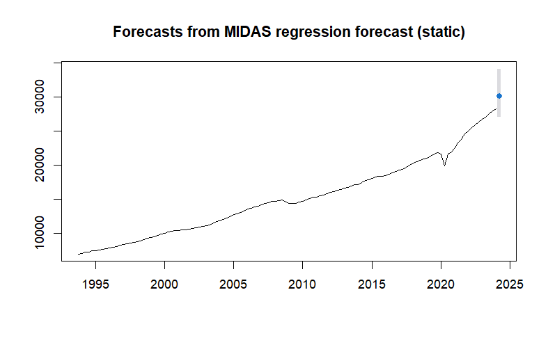

|  | Point Forecast | Lo 95 | Hi 95 |
| --- | --- | --- | --- |
| 2024 Q2 | 30137.69 | 27112.87 | 34142.28 |

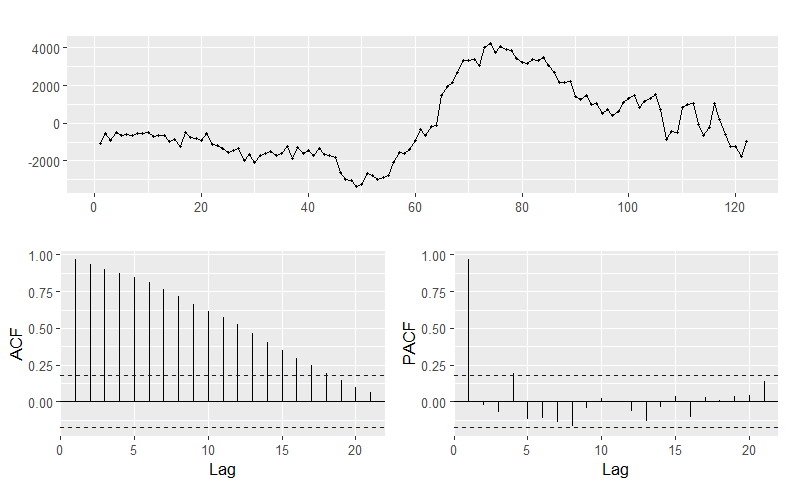

residus heteroscedasticiques, autocorreles Capacite predictive laisse a desirer

# **Prevision Out OF Sample (OOS)**

### MODELE BRIDGE

```
Call:
lm(formula = GDP ~ TTLCONS + lag_GDP, data = data_train)

Residuals:
    Min      1Q  Median      3Q     Max
-432.56  -29.11    1.10   44.07  180.86

Coefficients:
             Estimate Std. Error t value Pr(>|t|)
(Intercept) 64.099242  37.041211   1.730   0.0869 .
TTLCONS      0.025325   0.023010   1.101   0.2739
lag_GDP      0.999960   0.004038 247.636   <2e-16 ***
---
Signif. codes:  0 ‘***’ 0.001 ‘**’ 0.01 ‘*’ 0.05 ‘.’ 0.1 ‘ ’ 1

Residual standard error: 85.85 on 93 degrees of freedom
Multiple R-squared:  0.9995,    Adjusted R-squared:  0.9994
F-statistic: 8.527e+04 on 2 and 93 DF,  p-value: < 2.2e-16
```

Pour cette prevision OOS avec le modele de bridge, on note que le retard du PIB est la seul variable significative au niveau 5%. TTLCONS n’est pas significative alors qu’elle l’etait dans la prevision WS Le R2 est 99.95%, donc le modele est bien ajuste Le test de Fisher est significatif au niveau 5%, d’ou le modele est globalement satisfaisant

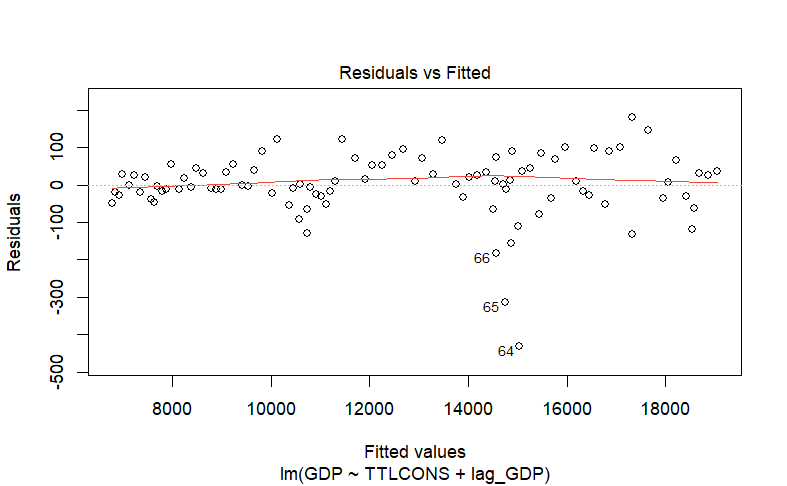

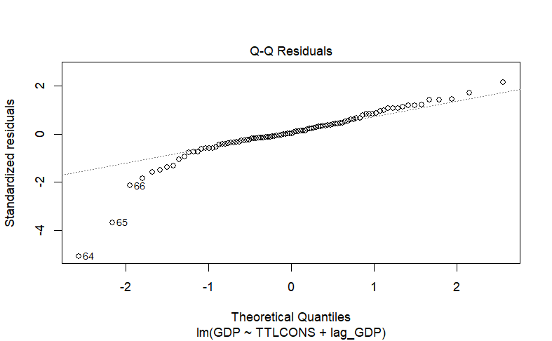

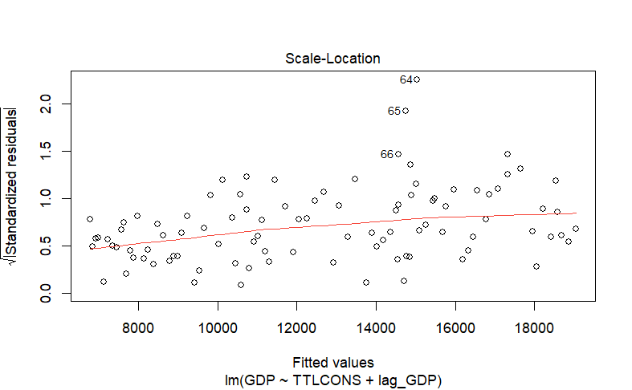

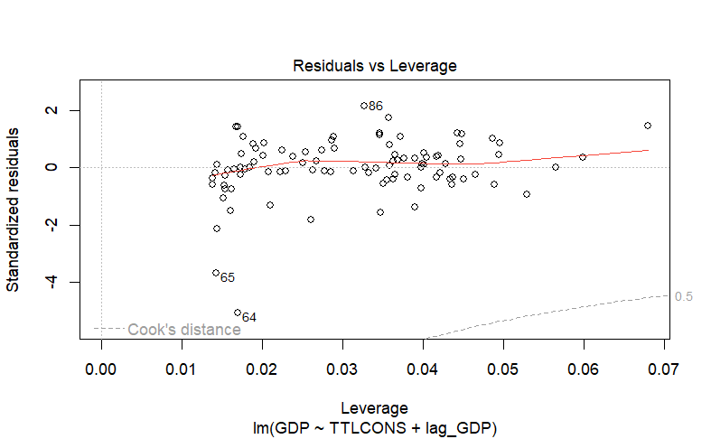

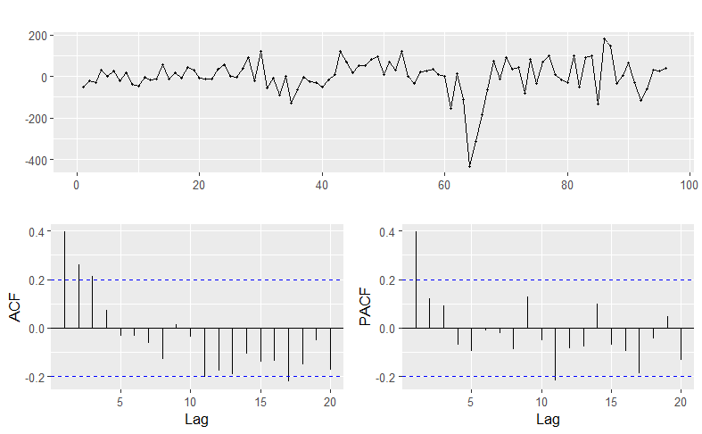

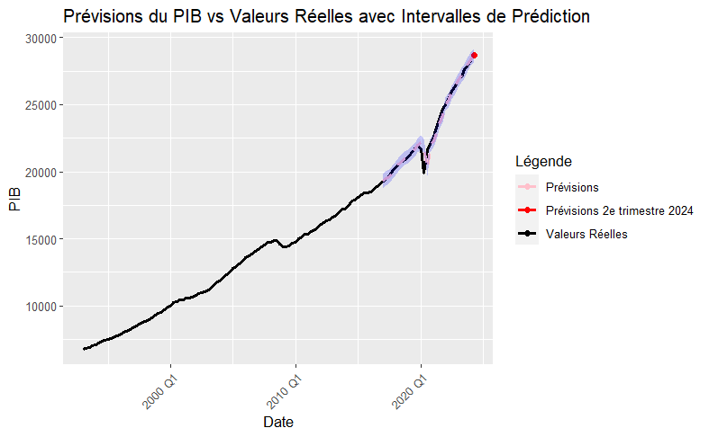

```
        fit      lwr      upr
30 28717.93 28192.53 29243.33
```

On peut voir sur l’ensemble de la periode de test, le modele predit bien le PIB, meme avec la baisse pendant la pandemie du Covid-19 en 2020 Il predit au 2e trimestre de 2024 un PIB de 28717.93 milliards de dollars, avec un intervalle de [28192.53,29243.33].

### Modele midas zero

```
MIDAS regression model with "ts" data:
Start = 1993(4), End = 2016(4)

 Formula GDP ~ mls(TTLCONS, 0:11, 3)

 Parameters:
            Estimate Std. Error t value Pr(>|t|)
(Intercept)  538.317   3574.001   0.151    0.881
TTLCONS1      19.481     24.561   0.793    0.430
TTLCONS2      19.713     38.553   0.511    0.611
TTLCONS3     -31.113     37.553  -0.829    0.410
TTLCONS4      -2.265     34.950  -0.065    0.948
TTLCONS5      13.629     51.053   0.267    0.790
TTLCONS6     -19.302     49.764  -0.388    0.699
TTLCONS7      -4.375     37.085  -0.118    0.906
TTLCONS8      31.464     50.643   0.621    0.536
TTLCONS9     -36.439     50.599  -0.720    0.474
TTLCONS10     11.229     43.609   0.257    0.797
TTLCONS11    -15.564     41.466  -0.375    0.708
TTLCONS12     27.601     21.649   1.275    0.206

 Residual standard error: 2299 on 80 degrees of freedom
```

Aucune variable n’est significative au niveau 5%.

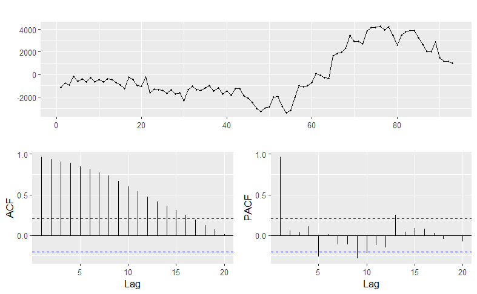

Residus tjrs heteroscedasticiques et autocorreles.

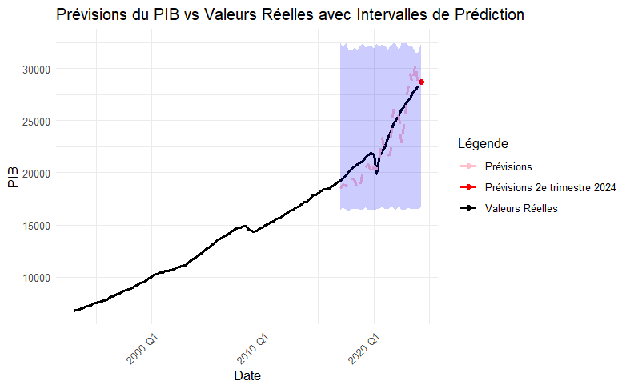

|  | Point Forecast | Lo 95 | Hi 95 |
| --- | --- | --- | --- |
| 2017 Q1 | 18504.38 | 16457.01 | 32482.91 |
| 2017 Q2 | 18886.18 | 16658.80 | 31987.90 |
| 2017 Q3 | 18724.04 | 16473.05 | 32432.33 |
| 2017 Q4 | 19446.06 | 16367.07 | 31774.35 |
| 2018 Q1 | 19385.61 | 16491.58 | 31722.34 |
| 2018 Q2 | 19457.72 | 16485.57 | 31967.82 |
| 2018 Q3 | 18429.31 | 16582.62 | 31797.57 |
| 2018 Q4 | 18494.35 | 16435.53 | 32188.13 |
| 2019 Q1 | 20292.41 | 16410.37 | 32363.34 |
| 2019 Q2 | 20567.56 | 16745.11 | 32012.44 |

[output cut: 20 more lines]

On peut remarquer qu’il y a une difference notable entre les valeurs relles et les previsions pour la prevision OOS du modele MIDAS zero. Ce qui n’est pas satisfaisant. prediction = 28696.91 et intervalle de prediction = [16416.86,32324.22] (IP beaucoup plus grand que celui du modele bridge)

### Modele midas non zero

```
MIDAS regression model with "ts" data:
Start = 1993(4), End = 2016(4)

 Formula GDP ~ mls(TTLCONS, 0:11, 3)

 Parameters:
            Estimate Std. Error t value Pr(>|t|)
(Intercept)  538.317   3574.001   0.151    0.881
TTLCONS1      19.481     24.561   0.793    0.430
TTLCONS2      19.713     38.553   0.511    0.611
TTLCONS3     -31.113     37.553  -0.829    0.410
TTLCONS4      -2.265     34.950  -0.065    0.948
TTLCONS5      13.629     51.053   0.267    0.790
TTLCONS6     -19.302     49.764  -0.388    0.699
TTLCONS7      -4.375     37.085  -0.118    0.906
TTLCONS8      31.464     50.643   0.621    0.536
TTLCONS9     -36.439     50.599  -0.720    0.474
TTLCONS10     11.229     43.609   0.257    0.797
TTLCONS11    -15.564     41.466  -0.375    0.708
TTLCONS12     27.601     21.649   1.275    0.206

 Residual standard error: 2299 on 80 degrees of freedom
```

IDEM que modele MIDAS Zero Cela signifie que Les données utilisées pour le modèle peuvent être suffisamment informatives pour guider le modèle vers des coefficients similaires, quelle que soit la valeur initiale.

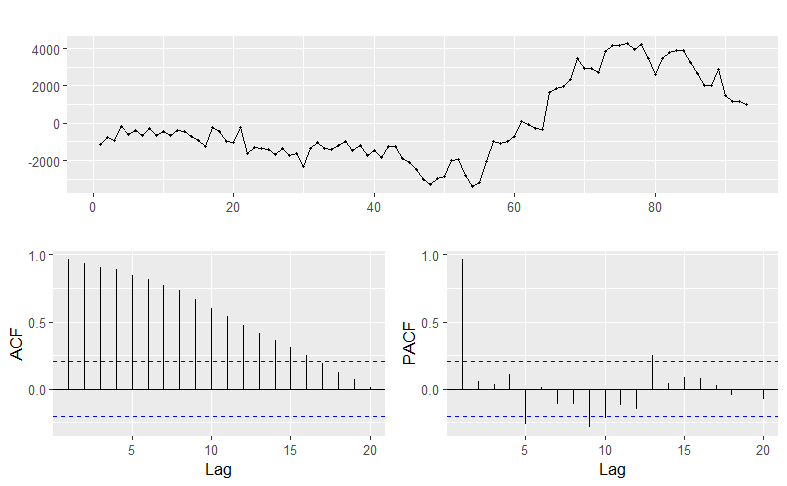

Residus tjrs heteroscedasticiques et autocorreles.

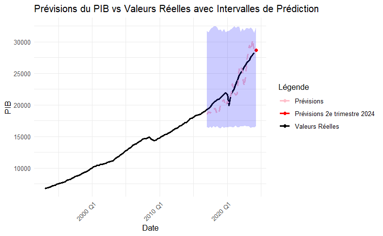

[output not shown]

METRIQUES

| Type | Modele | MAE | RMSE |
| --- | --- | --- | --- |
| Winthin Sample | Bridge | 103.3425 | 252.8721 |
| Winthin Sample | Midas Zero | 1631.6523 | 1938.9285 |
| Winthin Sample | Midas Non Zero | 1631.6523 | 1938.9285 |
| Out OF Sample | Bridge | 233.6108 | 496.5710 |
| Out OF Sample | Midas Zero | 1229.6417 | 1459.7227 |
| Out OF Sample | Midas Non Zero | 1229.6417 | 1459.7227 |

Ecart-type GDP = 5623 milliards de dollars et RMSE modele de bridge = 252,87 (WS) Ecart-type GDP = 5623 milliards de dollars et RMSE modele de bridge = 496,57 (OOS)